# Mar 7 2018

# Multivariate ANOVA

## Multivariate analysis of variance

- Standard ANOVA has just one response variable.
- What if you have more than one response?
- Try an ANOVA on each response separately.
- But might miss some kinds of interesting dependence between the responses that distinguish the groups.

## Packages

```r
library(car)
library(tidyverse)
```

## Small example

- Measure yield and seed weight of plants grown under 2 conditions: low and high amounts of fertilizer.
- Data (fertilizer, yield, seed weight):

```r
my_url="http://www.utsc.utoronto.ca/~butler/d29/manova1.txt"
hilo=read_delim(my_url," ")
```

- 2 responses, yield and seed weight.

## The data

```r
hilo
```

| fertilizer | yield | weight |
| --- | --- | --- |
| low | 34 | 10 |
| low | 29 | 14 |
| low | 35 | 11 |
| low | 32 | 13 |
| high | 33 | 14 |
| high | 38 | 12 |
| high | 34 | 13 |
| high | 35 | 14 |

## Boxplot for yield for each fertilizer group

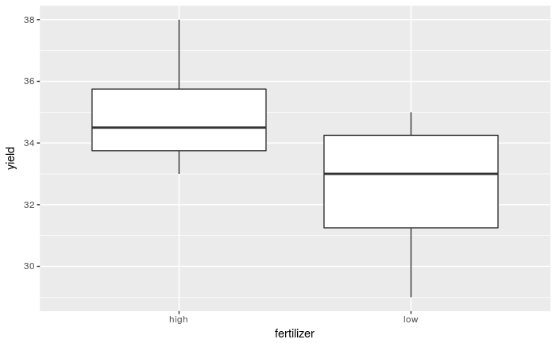

```r
ggplot(hilo,aes(x=fertilizer,y=yield))+geom_boxplot()
```

Yields overlap for fertilizer groups.

## Boxplot for weight for each fertilizer group

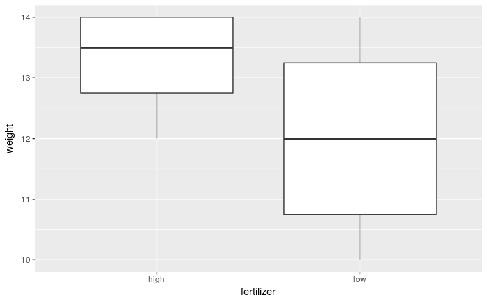

```r
ggplot(hilo,aes(x=fertilizer,y=weight))+geom_boxplot()
```

Weights overlap for fertilizer groups.

## ANOVAs for yield and weight

```r
hilo.y=aov(yield~fertilizer,data=hilo)
summary(hilo.y)
```

```
            Df Sum Sq Mean Sq F value Pr(>F)
fertilizer   1   12.5  12.500   2.143  0.194
Residuals    6   35.0   5.833
```

```r
hilo.w=aov(weight~fertilizer,data=hilo)
summary(hilo.w)
```

```
            Df Sum Sq Mean Sq F value Pr(>F)
fertilizer   1  3.125   3.125   1.471  0.271
Residuals    6 12.750   2.125
```

Neither response depends significantly on fertilizer. But…

## Plotting both responses at once

Have two response variables (not more), so can plot the response variables against *each other*, labelling points by which fertilizer group they’re from.

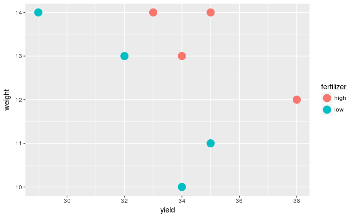

```r
g=ggplot(hilo,aes(x=yield,y=weight,
    colour=fertilizer))+geom_point(size=5)
g
```

Want line through points $(31,14)$ and $(38,10)$ (why? Later):

```r
d=tribble(
    ~line_x, ~line_y,
    31, 14,
    38, 10)
d
```

| line_x | line_y |
| --- | --- |
| 31 | 14 |
| 38 | 10 |

```r
g=g+geom_line(data=d,aes(x=line_x,y=line_y,
  colour=NULL))
```

## The plot

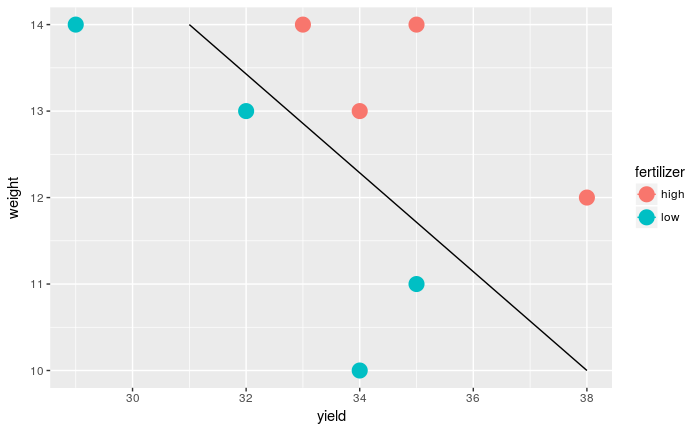

```r
g
```

## MANOVA

- High-fertilizer plants have both yield and weight high.
- True even though no sig difference in yield or weight individually.
- Drew line separating highs from lows on plot.

## MANOVA finds multivariate differences

- Is difference found by diagonal line significant? MANOVA finds out.

```r
response=with(hilo,cbind(yield,weight))
response
```

```
     yield weight
[1,]    34     10
[2,]    29     14
[3,]    35     11
[4,]    32     13
[5,]    33     14
[6,]    38     12
[7,]    34     13
[8,]    35     14
```

```r
hilo.1=manova(response~fertilizer,data=hilo)
summary(hilo.1)
```

```
           Df  Pillai approx F num Df den Df  Pr(>F)
fertilizer  1 0.80154   10.097      2      5 0.01755 *
Residuals   6
---
Signif. codes:  0 ‘***’ 0.001 ‘**’ 0.01 ‘*’ 0.05 ‘.’ 0.1 ‘ ’ 1
```

- Yes! Difference between groups is *diagonally*, not just up/down (weight) or left-right (yield). The *yield-weight combination* matters.

## Strategy

- Create new response variable by gluing together columns of responses, using `cbind`.
- Use `manova` with new response, looks like `lm` otherwise.
- With more than 2 responses, cannot draw graph. What then?
- If MANOVA test significant, cannot use Tukey. What then?
- Use **discriminant analysis** (of which more later).

## Another way to do MANOVA

Install (once) and load package `car`:

```r
library(car)
```

## Another way…

```r
hilo.2.lm=lm(response~fertilizer,data=hilo)
hilo.2=Manova(hilo.2.lm)
hilo.2
```

```
Type II MANOVA Tests: Pillai test statistic
           Df test stat approx F num Df den Df  Pr(>F)
fertilizer  1   0.80154   10.097      2      5 0.01755 *
---
Signif. codes:  0 ‘***’ 0.001 ‘**’ 0.01 ‘*’ 0.05 ‘.’ 0.1 ‘ ’ 1
```

- Same result as small-m `manova`.
- `Manova` will also do *repeated measures*, coming up later.

## Another example: peanuts

- Three different varieties of peanuts (mysteriously, 5, 6 and 8) planted in two different locations.
- Three response variables: `y`, `smk` and `w`.

```r
peanuts.orig=read_delim("peanuts.txt"," ")
peanuts.orig
```

| obs | location | variety | y | smk | w |
| --- | --- | --- | --- | --- | --- |
| 1 | 1 | 5 | 195.3 | 153.1 | 51.4 |
| 2 | 1 | 5 | 194.3 | 167.7 | 53.7 |
| 3 | 2 | 5 | 189.7 | 139.5 | 55.5 |
| 4 | 2 | 5 | 180.4 | 121.1 | 44.4 |
| 5 | 1 | 6 | 203.0 | 156.8 | 49.8 |
| 6 | 1 | 6 | 195.9 | 166.0 | 45.8 |
| 7 | 2 | 6 | 202.7 | 166.1 | 60.4 |
| 8 | 2 | 6 | 197.6 | 161.8 | 54.1 |
| 9 | 1 | 8 | 193.5 | 164.5 | 57.8 |
| 10 | 1 | 8 | 187.0 | 165.1 | 58.6 |

[output cut: 2 more lines]

## Setup for analysis

```r
peanuts = peanuts.orig %>%
  mutate(location=factor(location),
         variety=factor(variety))
response=with(peanuts,cbind(y,smk,w))
response
```

```
          y   smk    w
 [1,] 195.3 153.1 51.4
 [2,] 194.3 167.7 53.7
 [3,] 189.7 139.5 55.5
 [4,] 180.4 121.1 44.4
 [5,] 203.0 156.8 49.8
 [6,] 195.9 166.0 45.8
 [7,] 202.7 166.1 60.4
 [8,] 197.6 161.8 54.1
 [9,] 193.5 164.5 57.8
[10,] 187.0 165.1 58.6
[11,] 201.5 166.8 65.0
[12,] 200.0 173.8 67.2
```

## Analysis (using `Manova`)

```r
peanuts.1=lm(response~location*variety,data=peanuts)
peanuts.2=Manova(peanuts.1)
peanuts.2
```

```
Type II MANOVA Tests: Pillai test statistic
                 Df test stat approx F num Df den Df   Pr(>F)
location          1   0.89348  11.1843      3      4 0.020502 *
variety           2   1.70911   9.7924      6     10 0.001056 **
location:variety  2   1.29086   3.0339      6     10 0.058708 .
---
Signif. codes:  0 ‘***’ 0.001 ‘**’ 0.01 ‘*’ 0.05 ‘.’ 0.1 ‘ ’ 1
```

- Interaction not quite significant.
- Weak dependence of `(y,smk,w)` on the location-variety *combination.*
- Understanding that dependence beyond our scope right now.
- Come back to this with discriminant analysis.

# Repeated measures by profile analysis

## Repeated measures by profile analysis

- More than one response *measurement* for each subject. Might be
  - measurements of the same thing at different times
  - measurements of different but related things
- Generalization of matched pairs (``matched triples’’, etc.).
- Variation: each subject does several different treatments at different times (called *crossover design*).
- Expect measurements on same subject to be correlated, so assumptions of independence will fail.
- Called *repeated measures*. Different approaches, but *profile analysis* uses `Manova` (set up right way).
- Another approach uses *mixed models* (random effects).

## Packages

```r
library(car)
library(tidyverse)
```

## Example: histamine in dogs

- 8 dogs take part in experiment.
- Dogs randomized to one of 2 different drugs.
- Response: log of blood concentration of histamine 0, 1, 3 and 5 minutes after taking drug. (Repeated measures.)
- Data in `dogs.txt`, column-aligned.

## Read in data

```r
my_url="http://www.utsc.utoronto.ca/~butler/d29/dogs.txt"
dogs=read_table(my_url)
```

## Setting things up

```r
dogs
```

| dog | drug | x | lh0 | lh1 | lh3 | lh5 |
| --- | --- | --- | --- | --- | --- | --- |
| A | Morphine | N | -3.22 | -1.61 | -2.30 | -2.53 |
| B | Morphine | N | -3.91 | -2.81 | -3.91 | -3.91 |
| C | Morphine | N | -2.66 | 0.34 | -0.73 | -1.43 |
| D | Morphine | N | -1.77 | -0.56 | -1.05 | -1.43 |
| E | Trimethaphan | N | -3.51 | -0.48 | -1.17 | -1.51 |
| F | Trimethaphan | N | -3.51 | 0.05 | -0.31 | -0.51 |
| G | Trimethaphan | N | -2.66 | -0.19 | 0.07 | -0.22 |
| H | Trimethaphan | N | -2.41 | 1.14 | 0.72 | 0.21 |

```r
response=with(dogs,cbind(lh0,lh1,lh3,lh5))
response
```

```
       lh0   lh1   lh3   lh5
[1,] -3.22 -1.61 -2.30 -2.53
[2,] -3.91 -2.81 -3.91 -3.91
[3,] -2.66  0.34 -0.73 -1.43
[4,] -1.77 -0.56 -1.05 -1.43
[5,] -3.51 -0.48 -1.17 -1.51
[6,] -3.51  0.05 -0.31 -0.51
[7,] -2.66 -0.19  0.07 -0.22
[8,] -2.41  1.14  0.72  0.21
```

```r
dogs.lm=lm(response~drug,data=dogs)
```

## The repeated measures MANOVA

Get list of response variable names; we call them `times`. Save in data frame.

```r
class(response)
```

```
[1] "matrix"
```

```r
times=colnames(response)
times
```

```
[1] "lh0" "lh1" "lh3" "lh5"
```

```r
times.df=data.frame(times)
times.df
```

| times |
| --- |
| lh0 |
| lh1 |
| lh3 |
| lh5 |

```r
dogs.manova=Manova(dogs.lm,idata=times.df,
     idesign=~times)
dogs.manova
```

```
Type II Repeated Measures MANOVA Tests: Pillai test statistic
            Df test stat approx F num Df den Df   Pr(>F)
(Intercept)  1   0.76347  19.3664      1      6 0.004565 **
drug         1   0.34263   3.1272      1      6 0.127406
times        1   0.94988  25.2690      3      4 0.004631 **
drug:times   1   0.89476  11.3362      3      4 0.020023 *
---
Signif. codes:  0 ‘***’ 0.001 ‘**’ 0.01 ‘*’ 0.05 ‘.’ 0.1 ‘ ’ 1
```

Interaction significant. Pattern of response over time different for the two drugs.

## Wide and long format

- Want to investigate interaction.
- But data frame has several observations per line (``wide format’’):

```r
dogs
```

| dog | drug | x | lh0 | lh1 | lh3 | lh5 |
| --- | --- | --- | --- | --- | --- | --- |
| A | Morphine | N | -3.22 | -1.61 | -2.30 | -2.53 |
| B | Morphine | N | -3.91 | -2.81 | -3.91 | -3.91 |
| C | Morphine | N | -2.66 | 0.34 | -0.73 | -1.43 |
| D | Morphine | N | -1.77 | -0.56 | -1.05 | -1.43 |
| E | Trimethaphan | N | -3.51 | -0.48 | -1.17 | -1.51 |
| F | Trimethaphan | N | -3.51 | 0.05 | -0.31 | -0.51 |
| G | Trimethaphan | N | -2.66 | -0.19 | 0.07 | -0.22 |
| H | Trimethaphan | N | -2.41 | 1.14 | 0.72 | 0.21 |

- Plotting works with data in ``long format’’: one response per line.
- The responses are log-histamine at different times, labelled `lh`-something. Call them all `lh` and put them in one column, with the time they belong to labelled.

## Running `gather`, try 1

```r
dogs %>% gather(time,lh,lh0:lh5)
```

| dog | drug | x | time | lh |
| --- | --- | --- | --- | --- |
| A | Morphine | N | lh0 | -3.22 |
| B | Morphine | N | lh0 | -3.91 |
| C | Morphine | N | lh0 | -2.66 |
| D | Morphine | N | lh0 | -1.77 |
| E | Trimethaphan | N | lh0 | -3.51 |
| F | Trimethaphan | N | lh0 | -3.51 |
| G | Trimethaphan | N | lh0 | -2.66 |
| H | Trimethaphan | N | lh0 | -2.41 |
| A | Morphine | N | lh1 | -1.61 |
| B | Morphine | N | lh1 | -2.81 |

[output cut: 22 more lines]

## Getting the times

Not quite right: for the times, we want just the numbers, not the letters `lh` every time. Want new variable containing just number in `time`: `parse\_number`.

```r
dogs %>% gather(timex,lh,lh0:lh5) %>%
    mutate(time=parse_number(timex))
```

| dog | drug | x | timex | lh | time |
| --- | --- | --- | --- | --- | --- |
| A | Morphine | N | lh0 | -3.22 | 0 |
| B | Morphine | N | lh0 | -3.91 | 0 |
| C | Morphine | N | lh0 | -2.66 | 0 |
| D | Morphine | N | lh0 | -1.77 | 0 |
| E | Trimethaphan | N | lh0 | -3.51 | 0 |
| F | Trimethaphan | N | lh0 | -3.51 | 0 |
| G | Trimethaphan | N | lh0 | -2.66 | 0 |
| H | Trimethaphan | N | lh0 | -2.41 | 0 |
| A | Morphine | N | lh1 | -1.61 | 1 |
| B | Morphine | N | lh1 | -2.81 | 1 |

[output cut: 22 more lines]

## What I did differently}

- I realized that `gather` was going to produce something like `lh1`, which I needed to do something further with, so this time I gave it a temporary name `timex`.
- This enabled me to use the name `time` for the actual numeric time.
- This works now, so next save into a new data frame `dogs.long`.

## Saving the results

```r
dogs.long = dogs %>% gather(timex,lh,lh0:lh5) %>%
    mutate(time=parse_number(timex))
```

This says:

- Take data frame dogs, and then:
- Combine the columns `lh0` through `lh5` into one column called `lh`, with the column that each `lh` value originally came from labelled by `timex`, and then:
- Pull out numeric values in `timex`, saving in `time` and then:
- save the result in a data frame `dogs.long`.

## Spaghetti plot

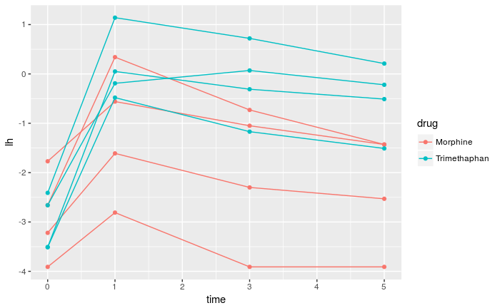

```r
ggplot(dogs.long,aes(x=time,y=lh,colour=drug,group=dog))+
  geom_point()+geom_line()
```

## Interaction plot

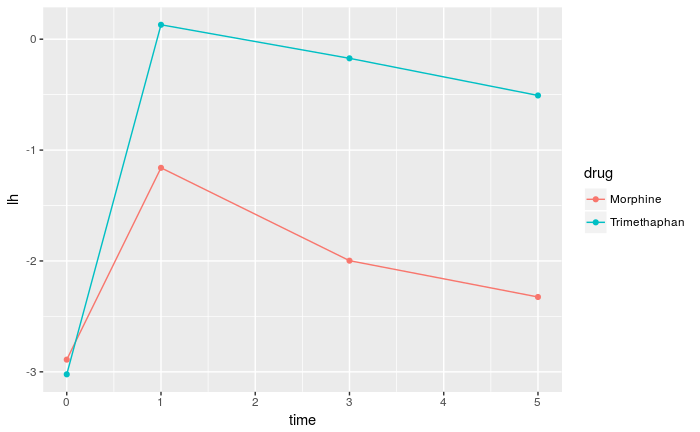

```r
ggplot(dogs.long,aes(x=time,y=lh,
                     colour=drug,group=drug))+
  stat_summary(fun.y=mean,geom="point")+
  stat_summary(fun.y=mean,geom="line")
```

## Comments

- Plot mean `lh` value at each time, joining points on same drug by lines.
- drugs same at time 0
- after that, Trimethaphan higher than Morphine.
- Effect of drug not consistent over time: significant interaction.

## Take out time zero

- Lines on interaction plot would then be parallel, and so interaction should no longer be significant.
- Go back to original ``wide''`dogs` data frame.

```r
response=with(dogs,cbind(lh1,lh3,lh5)) # excluding time zero
dogs.lm=lm(response~drug,data=dogs)
times=colnames(response)
times.df=data.frame(times)
dogs.manova=Manova(dogs.lm,idata=times.df,
                   idesign=~times)
```

## Results and comments

```r
dogs.manova
```

```
Type II Repeated Measures MANOVA Tests: Pillai test statistic
            Df test stat approx F num Df den Df   Pr(>F)
(Intercept)  1   0.54582   7.2106      1      6 0.036281 *
drug         1   0.44551   4.8207      1      6 0.070527 .
times        1   0.85429  14.6569      2      5 0.008105 **
drug:times   1   0.43553   1.9289      2      5 0.239390
---
Signif. codes:  0 ‘***’ 0.001 ‘**’ 0.01 ‘*’ 0.05 ‘.’ 0.1 ‘ ’ 1
```

- Correct: interaction no longer significant.
- Significant effect of time.
- Drug effect not quite significant (some variety among dogs within drug).

## Is the non-significant drug effect reasonable?

- Plot *actual data*: `lh` against `days`, labelling observations by drug: ``spaghetti plot’’.
- Uses long data frame (confusing, yes I know):
- Plot (time,lh) points coloured by drug
- and connecting measurements for each *dog* by lines.
- This time, we want `group=dog` (want the measurements for each *dog* joined by lines), but `colour=drug`:

```r
g=ggplot(dogs.long,aes(x=time,y=lh,
    colour=drug,group=dog)) +
  geom_point()+geom_line()
```

## The spaghetti plot

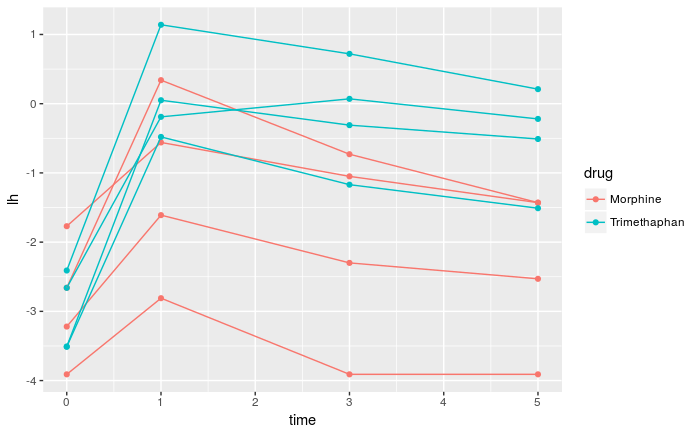

```r
g
```

## Comments

- For each dog over time, there is a strong increase and gradual decrease in log-histamine. This explains the significant time effect.
- The pattern is more or less the same for each dog, regardless of drug. This explains the non-significant interaction.
- Most of the trimethaphan dogs (blue) have higher log-histamine throughout (time 1 and after), and some of the morphine dogs have lower.
- *But* two of the morphine dogs have log-histamine profiles like the trimethaphan dogs. This ambiguity is probably why the `drug` effect is not quite significant.

## Mixed models

- Another way to fit repeated measures
- Subjects (on whom repeated measures taken) are *random sample of all possible subjects* (random effects)
- Times and treatments are *the only ones we care about* (fixed effects)
- Use package `lme4` function `lmer` (like `lm` in some ways)
- Uses long-format “tidy” data

## Fitting the model

```r
library(lme4)
dogs.long
```

| dog | drug | x | timex | lh | time |
| --- | --- | --- | --- | --- | --- |
| A | Morphine | N | lh0 | -3.22 | 0 |
| B | Morphine | N | lh0 | -3.91 | 0 |
| C | Morphine | N | lh0 | -2.66 | 0 |
| D | Morphine | N | lh0 | -1.77 | 0 |
| E | Trimethaphan | N | lh0 | -3.51 | 0 |
| F | Trimethaphan | N | lh0 | -3.51 | 0 |
| G | Trimethaphan | N | lh0 | -2.66 | 0 |
| H | Trimethaphan | N | lh0 | -2.41 | 0 |
| A | Morphine | N | lh1 | -1.61 | 1 |
| B | Morphine | N | lh1 | -2.81 | 1 |

[output cut: 22 more lines]

```r
dogs.2=lmer(lh~drug*time+(1|dog),data=dogs.long)
```

- note specification of random effect: each dog has “random intercept” that moves log-histamine up or down for that dog over all times

## What can we drop?

- using `drop1`:

```r
drop1(dogs.2,test="Chisq")
```

```
Single term deletions

Model:
lh ~ drug * time + (1 | dog)
          Df    AIC    LRT Pr(Chi)
<none>       113.26
drug:time  1 114.21 2.9534  0.0857 .
---
Signif. codes:  0 ‘***’ 0.001 ‘**’ 0.01 ‘*’ 0.05 ‘.’ 0.1 ‘ ’ 1
```

- Interaction again not significant, but P-value smaller than before

## Re-fit without interaction

```r
dogs.3=update(dogs.2,.~.-drug:time)
drop1(dogs.3,test="Chisq")
```

```
Single term deletions

Model:
lh ~ drug + time + (1 | dog)
       Df    AIC    LRT Pr(Chi)
<none>    114.21
drug    1 115.57 3.3560 0.06696 .
time    1 114.96 2.7501 0.09725 .
---
Signif. codes:  0 ‘***’ 0.001 ‘**’ 0.01 ‘*’ 0.05 ‘.’ 0.1 ‘ ’ 1
```

- This time neither drug nor (surprisingly) time is significant.
- MANOVA and `lmer` methods won’t agree, but both valid ways to approach problem.

## The exercise data

- 30 people took part in an exercise study.
- Each subject was randomly assigned to one of two diets (`low fat'' or`non-low fat’‘) and to one of three exercise programs (`at rest'',`walking’‘, ``running’’).
- There are $2\times3 = 6$ experimental treatments, and thus each one is replicated $30/6=5$ times.
- Nothing unusual so far.
- However, each subject had their pulse rate measured at three different times (1, 15 and 30 minutes after starting their exercise), so have repeated measures.

## Reading the data

Separated by *tabs*:

```r
my_url="http://www.utsc.utoronto.ca/~butler/d29/exercise.txt"
exercise.long=read_tsv(my_url)
```

## The data

```r
exercise.long
```

| id | diet | exertype | pulse | time |
| --- | --- | --- | --- | --- |
| 1 | nonlowfat | atrest | 85 | min01 |
| 1 | nonlowfat | atrest | 85 | min15 |
| 1 | nonlowfat | atrest | 88 | min30 |
| 2 | nonlowfat | atrest | 90 | min01 |
| 2 | nonlowfat | atrest | 92 | min15 |
| 2 | nonlowfat | atrest | 93 | min30 |
| 3 | nonlowfat | atrest | 97 | min01 |
| 3 | nonlowfat | atrest | 97 | min15 |
| 3 | nonlowfat | atrest | 94 | min30 |
| 4 | nonlowfat | atrest | 80 | min01 |

[output cut: 80 more lines]

- This is ``long format’’, which is usually what we want.
- But for repeated measures analysis, we want *wide* format!
- ``undo'' gather:`spread`.

## Making wide format

- Spread needs three things: a data frame, a column that is going to be split, and the column to make the values out of:

```r
exercise.wide=exercise.long %>% spread(time,pulse)
exercise.wide
```

| id | diet | exertype | min01 | min15 | min30 |
| --- | --- | --- | --- | --- | --- |
| 1 | nonlowfat | atrest | 85 | 85 | 88 |
| 2 | nonlowfat | atrest | 90 | 92 | 93 |
| 3 | nonlowfat | atrest | 97 | 97 | 94 |
| 4 | nonlowfat | atrest | 80 | 82 | 83 |
| 5 | nonlowfat | atrest | 91 | 92 | 91 |
| 6 | lowfat | atrest | 83 | 83 | 84 |
| 7 | lowfat | atrest | 87 | 88 | 90 |
| 8 | lowfat | atrest | 92 | 94 | 95 |
| 9 | lowfat | atrest | 97 | 99 | 96 |
| 10 | lowfat | atrest | 100 | 97 | 100 |

[output cut: 20 more lines]

- See how we would normally `gather` into one column called `pulse` labelled by the number of minutes? But `Manova` needs it the other way.

## Setting up the repeated-measures analysis

- Make a response variable consisting of `min01, min15, min30`:

```r
response=with(exercise.wide,
           cbind(min01, min15, min30))
```

- Predict that from `diet` and `exertype` and interaction using `lm`:

```r
exercise.1=lm(response~diet*exertype,
  data=exercise.wide)
response
```

```
      min01 min15 min30
 [1,]    85    85    88
 [2,]    90    92    93
 [3,]    97    97    94
 [4,]    80    82    83
 [5,]    91    92    91
 [6,]    83    83    84
 [7,]    87    88    90
 [8,]    92    94    95
 [9,]    97    99    96
[10,]   100    97   100
[11,]    86    86    84
[12,]    93   103   104
[13,]    90    92    93
[14,]    95    96   100
```

[output cut: 16 more lines]

- Run this through `Manova`:

```r
times=colnames(response)
times.df=data.frame(times)
exercise.2=Manova(exercise.1,idata=times.df,
                  idesign=~times)
```

## Results

```r
exercise.2
```

```
Type II Repeated Measures MANOVA Tests: Pillai test statistic
                    Df test stat approx F num Df den Df    Pr(>F)
(Intercept)          1   0.99767  10296.7      1     24 < 2.2e-16 ***
diet                 1   0.37701     14.5      1     24 0.0008483 ***
exertype             2   0.79972     47.9      2     24 4.166e-09 ***
diet:exertype        2   0.28120      4.7      2     24 0.0190230 *
times                1   0.78182     41.2      2     23 2.491e-08 ***
diet:times           1   0.25153      3.9      2     23 0.0357258 *
exertype:times       2   0.83557      8.6      4     48 2.538e-05 ***
diet:exertype:times  2   0.51750      4.2      4     48 0.0054586 **
---
Signif. codes:  0 ‘***’ 0.001 ‘**’ 0.01 ‘*’ 0.05 ‘.’ 0.1 ‘ ’ 1
```

- Three-way interaction significant, so cannot remove anything.
- Pulse rate depends on diet and exercise type *combination*, and *that* is different for each time.

## Making some graphs

- Three-way interactions are difficult to understand. To make an attempt, look at some graphs.
- Plot time trace of pulse rates for each individual, joined by lines, and make *separate* plots for each `diet-exertype` combo.
- `ggplot` again. Using *long* data frame:

```r
exercise.long
```

| id | diet | exertype | pulse | time |
| --- | --- | --- | --- | --- |
| 1 | nonlowfat | atrest | 85 | min01 |
| 1 | nonlowfat | atrest | 85 | min15 |
| 1 | nonlowfat | atrest | 88 | min30 |
| 2 | nonlowfat | atrest | 90 | min01 |
| 2 | nonlowfat | atrest | 92 | min15 |
| 2 | nonlowfat | atrest | 93 | min30 |
| 3 | nonlowfat | atrest | 97 | min01 |
| 3 | nonlowfat | atrest | 97 | min15 |
| 3 | nonlowfat | atrest | 94 | min30 |
| 4 | nonlowfat | atrest | 80 | min01 |

[output cut: 80 more lines]

Try 1

Use exercise type as colour and diet as shape, grouping by subject id

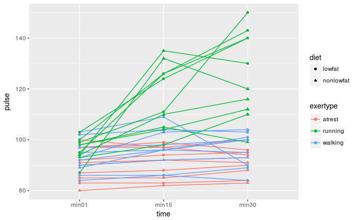

```r
ggplot(exercise.long,aes(x=time,y=pulse,colour=exertype,shape=diet,group=id))+
  geom_point()+geom_line()
```

Confusing. How about separate *facets* for diet and exercise type?

```r
g=ggplot(exercise.long,aes(x=time,y=pulse,
  group=id))+geom_point()+geom_line()+
  facet_grid(diet~exertype)
```

- `facet_grid(diet~exertype)`: do a separate plot for each combination of diet and exercise type, with diets going down the page and exercise types going across. (Graphs are usually landscape, so have the factor `exertype` with more levels going across.)

## The graph(s)

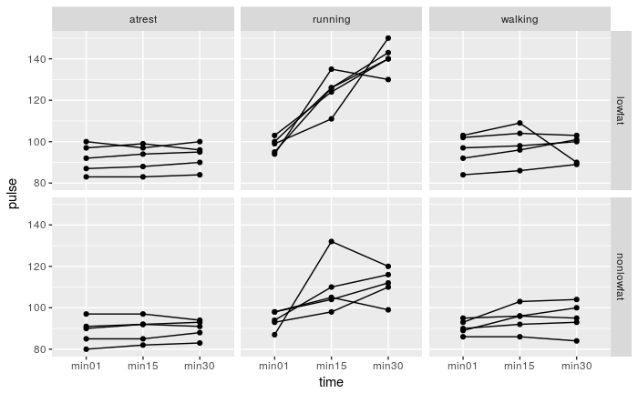

```r
g
```

## Comments on graphs

- For subjects who were at rest, no change in pulse rate over time, for both diet groups.
- For walking subjects, not much change in pulse rates over time. Maybe a small increase on average between 1 and 15 minutes.
- For both running groups, an overall increase in pulse rate over time, but the increase is stronger for the `lowfat` group.
- No consistent effect of diet over all exercise groups.
- No consistent effect of exercise type over both diet groups.
- No consistent effect of time over all diet-exercise type combos.

## ``Simple effects’’ of diet for the subjects who ran

- Looks as if there is only any substantial time effect for the runners. For them, does diet have an effect?
- Pull out only the runners from the wide data:

```r
runners.wide = exercise.wide %>%
  filter(exertype=="running")
```

- Create response variable and do MANOVA. Some of this looks like before, but I have different data now:

```r
response=with(runners.wide,cbind(min01,min15,min30))
runners.1=lm(response~diet,data=runners.wide)
times=colnames(response)
times.df=data.frame(times)
runners.2=Manova(runners.1,idata=times.df,
                 idesign=~times)
```

## Results`

```r
runners.2
```

```
Type II Repeated Measures MANOVA Tests: Pillai test statistic
            Df test stat approx F num Df den Df    Pr(>F)
(Intercept)  1   0.99912   9045.3      1      8 1.668e-13 ***
diet         1   0.84986     45.3      1      8 0.0001482 ***
times        1   0.92493     43.1      2      7 0.0001159 ***
diet:times   1   0.68950      7.8      2      7 0.0166807 *
---
Signif. codes:  0 ‘***’ 0.001 ‘**’ 0.01 ‘*’ 0.05 ‘.’ 0.1 ‘ ’ 1
```

- The `diet` by `time` interaction is still significant (at $\alpha=0.05$): the effect of time on pulse rates is different for the two diets.
- At $\alpha=0.01$, the interaction is not significant, and then we have only two (very) significant main effects of `diet` and `time`.

## How is the effect of diet different over time?

- Table of means. Only I need long data for this, so make it (in a pipeline):

```r
summ = runners.wide %>%
  gather(time,pulse,min01:min30) %>%
  group_by(time,diet) %>%
  summarize(mean_pulse=mean(pulse))
```

## Understanding diet-time interaction

```
-  The summary:
```

```r
summ
```

| time | diet | mean_pulse |
| --- | --- | --- |
| min01 | lowfat | 98.2 |
| min01 | nonlowfat | 94.0 |
| min15 | lowfat | 124.4 |
| min15 | nonlowfat | 109.8 |
| min30 | lowfat | 140.6 |
| min30 | nonlowfat | 111.4 |

- Pulse rates at any given time higher for `lowfat` (diet effect),
- Pulse rates increase over time of exercise (time effect),
- but the *amount by which pulse rate higher* for a diet depends on time: `diet` by `time` interaction.

## Interaction plot

- We went to trouble of finding means by group, so making interaction plot is now mainly easy:

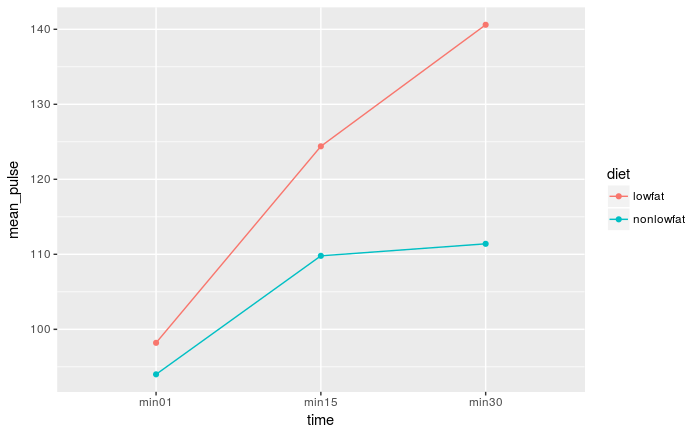

```r
ggplot(summ,aes(x=time,y=mean_pulse,colour=diet,
  group=diet))+geom_point()+geom_line()
```

- The lines are not parallel, so there is interaction between diet and time: the difference in mean pulse rate is getting bigger.